# slashdot-ai-hype

Short exploration of the rise (and fall) of hype-laden buzzwords announcing the impending domination of the world by sentient computers.

### Background

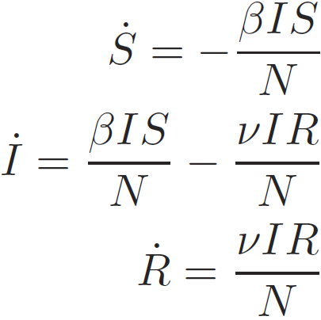

### Approach

The approach is to fit the normalized popularity data using the irSIR model. The fit is performed in Bayesian fashion. Namely, a generative model is specified that completely describes the data generation process:

- temporal evolution of the sate using ODEs, and
- subsequent addition of a Poisson-like noise.

As the absolute scale is not known, the noise is approximated by a normal distribution whose width is proportional to the square root of the normalized popularity score. This approach has shown to be able to adequately describe the observed variability.

**The key principle is to try to include *all* uncertainties into prediction.**

Coupled with weak uninformative priors we obtain the *posterior predictive distribution* of the normalized popularity. The model can also be extrapolated into the future.

The model is implemented in the [Stan](http://mc-stan.org/) probabilistic programming language, which uses the advanced NUTS MCMC sampling algorithm.

Of course, it goes without saying that even the Bayesian approach cannot account for fitting the wrong model ;-)

### Example fits of irSIR model

Fit of Google Trends data for the Facebook and LinkedIn search strings.

The model is fitted to the data up to 2017-05-01. The remaining data will be used for ongoing validation. I am genuinely curious about how accurate the predictions will turn out to be.

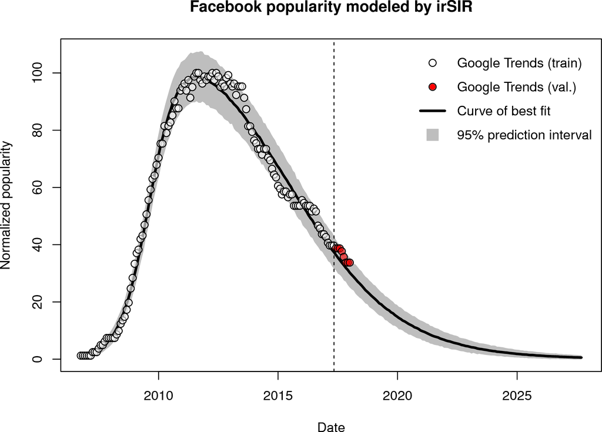

Facebook fit

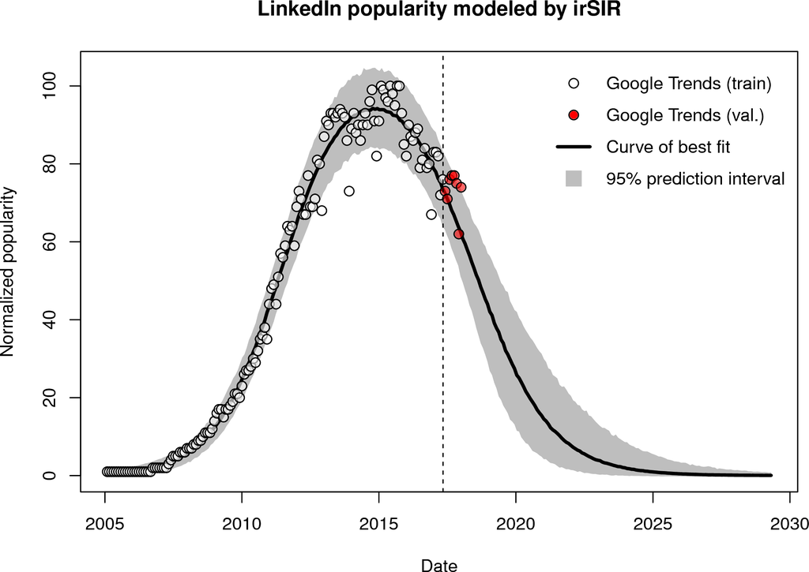

LinkedIn fit

### Related example (FOMO/FUD model)

Below is a slightly different model shown fitting to the Cryptocurrency Google Trends keyword. The model builds upon the ideas of the irSIR model and I call it the *FOMO/FUD* model.

The differential evolution equations are similar to irSIR, but the $S I/N$ and $I R/N$ terms are replaced with $S\cdot I^2/N^2$ and $I R^2/N^2$. The square terms try to approximate the *perceived value* of belonging to a particular sub-group modeled by Metcalfe’s law.

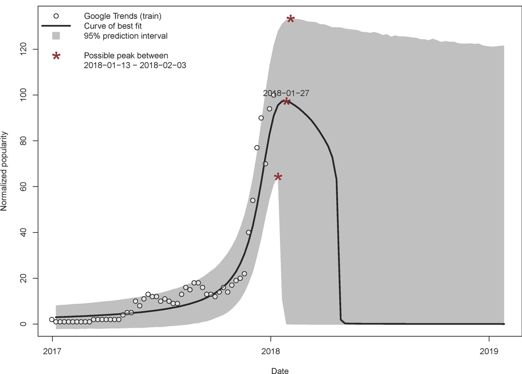

Cryptocurrency fit